# Prosper Loan Explanatory analysis

## Effectiveness of Prosper score as compared to other variables

> In this analysis, we will look at the effectiveness of prosper score as an instrument to identify risk of borrowers and how it stacks up against other variables

```python
# import all packages and set plots to be embedded inline
import numpy as np
import pandas as pd
import matplotlib.pyplot as plt
import seaborn as sb
import statsmodels

%matplotlib inline

import warnings
warnings.simplefilter("ignore")
```

```python
source_df = pd.read_csv('prosperLoanData.csv')
```

> Quite a Large dataset, have to select the interested columns to narrow down the analysis

```python
credit_rating_factors = ['EmploymentStatus','IsBorrowerHomeowner','CreditGrade','CreditScoreRangeLower','CreditScoreRangeUpper','OpenRevolvingAccounts','CurrentDelinquencies','AmountDelinquent','BankcardUtilization','AvailableBankcardCredit','EmploymentStatusDuration','TotalProsperPaymentsBilled','OnTimeProsperPayments']
interested_columns = ['CreditGrade','LoanStatus','ListingCreationDate','ListingCategory (numeric)','BorrowerRate','EstimatedReturn','ProsperRating (Alpha)','ProsperScore','EmploymentStatus','DebtToIncomeRatio','StatedMonthlyIncome','LoanOriginalAmount','MonthlyLoanPayment']
```

```python
df = source_df[interested_columns]
credit_df = source_df[credit_rating_factors]
```

**Combine Prosper Rating & credit grade into one column**

> Combining Prosper Rating & Credit Grade into one column and coverting them to ordinal category data. As per the variables definition, seems to contain same type of information

```python
df['ProsperRating (Alpha)'].fillna(df['CreditGrade'],inplace=True)
df=df.drop(['CreditGrade'],1)
df.rename(columns={'ProsperRating (Alpha)':'Credit_Rating'}, inplace=True)
```

```python
rating_order = ['HR','E','D','C','B','A','AA']
df['Credit_Rating']=df['Credit_Rating'].astype(pd.api.types.CategoricalDtype(ordered = True, categories = rating_order))
df['Credit_Rating'].value_counts()
```

```
C     23994
B     19970
D     19427
A     17866
E     13084
HR    10443
AA     8881
Name: Credit_Rating, dtype: int64
```

**Consolidating values in Loan Status**

> There seems to be many values which are past due but with different aging period. Combining this to one value will make this column simpler to analyze

```python
df['LoanStatus']=df['LoanStatus'].apply(lambda x:'Past Due' if 'Past' in x else x)
```

```python
status_order = ['Defaulted','Chargedoff','Past Due','Current','FinalPaymentInProgress','Completed']
df['LoanStatus']=df['LoanStatus'].astype(pd.api.types.CategoricalDtype(ordered = True, categories = status_order))
```

> Loan status values can furthur be consolidated into two sets of values: good loan & bad loan for simpler analysis. **Creating a new column 'Loan quality' for the same while retaining loan status for granular analysis**

```python
df['Quality_of_Loan'] = df['LoanStatus']
```

```python
df['Quality_of_Loan'].replace('Defaulted','Bad Loan',inplace=True)
df['Quality_of_Loan'].replace('Chargedoff','Bad Loan',inplace=True)
df['Quality_of_Loan'].replace('Past Due','Bad Loan',inplace=True)
```

```python
df['Quality_of_Loan'].replace('Completed','Good Loan',inplace=True)
df['Quality_of_Loan'].replace('FinalPaymentInProgress','Good Loan',inplace=True)
df['Quality_of_Loan'].replace('Current',np.nan,inplace=True)
df['Quality_of_Loan'].value_counts()
```

```
Good Loan    38279
Bad Loan     19077
Name: Quality_of_Loan, dtype: int64
```

> Creating Monthly_Income_Range as ordinal categorical data in place of income range

```python
salary_bins=[0,2500,5000,7500,10000,12500,np.inf]
range_labels = ["< 2500","2501-5000","5001-7500","7501-10000","10000-12500","> 12.5k"]
```

```python
df['Monthly_Income_Range']=pd.cut(df['StatedMonthlyIncome'],bins=salary_bins,labels=range_labels)
```

```python
df['Monthly_Income_Range']=df['Monthly_Income_Range'].astype(pd.api.types.CategoricalDtype(ordered = True, categories = range_labels))
```

```python
listing_codes_values = {0 : 'Not Available', 1 : 'Debt Consolidation', 2 : 'Home Improvement', 3: 'Business',
             4 : 'Personal Loan', 5 : 'Student Use', 6 : 'Auto', 7 : 'Other', 8 : 'Baby&Adoption',
             9 : 'Boat', 10 : 'Cosmetic Procedure', 11 : 'Engagement Ring', 12 : 'Green Loans',
             13 : 'Household Expenses', 14 : 'Large Purchases', 15 : 'Medical/Dental', 16 : 'Motorcycle',
             17 : 'RV', 18 : 'Taxes', 19 : 'Vacation', 20 : 'Wedding Loans'}
df['listing_category']=df['ListingCategory (numeric)'].map(listing_codes_values)
df=df.drop(['ListingCategory (numeric)'],1)
```

```python
# Carving out the data with bad loan & good loan as two separate data frames to be used when required
df_bad_loan = df[df['Quality_of_Loan']=='Bad Loan']
df_bad_loan=df_bad_loan.drop(['Quality_of_Loan'],1)
df_good_loan = df[df['Quality_of_Loan']=='Good Loan']
df_good_loan=df_good_loan.drop(['Quality_of_Loan'],1)
```

**Borrower Rate vs Debt to Income ratio**

> This was expected to have strong positive correlation. Higher the debt to income higher will be the borrower rate. But understandably borrower rate hits a ceiling around 0.31 to 0.35 mark weakening the correlation coefficient. Of course you cannot keep increasing borrower rate forever, which will make your platform unattractive for users with high debt. Believe adding Credit_Rating will throw more light into this hypothesis.

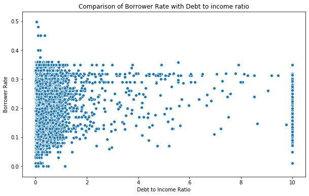

```python
f, ax = plt.subplots(figsize=(10, 6))
sb.scatterplot(data=df,y='BorrowerRate',x='DebtToIncomeRatio')
ax.set_title('Comparison of Borrower Rate with Debt to income ratio')
ax.set_xlabel('Debt to Income Ratio')
ax.set_ylabel('Borrower Rate')
```

**Loan Status vs Prosper Score**

> Loan Status vs Prosper Score : If prosper score signifies risk, then more defaulters should be in lower score range while high scores having more completed loans. This trend broadly holds good with this plot as we move from defaulted to completed loans, although defaulted loans are evenly spread above and below 6 mark.

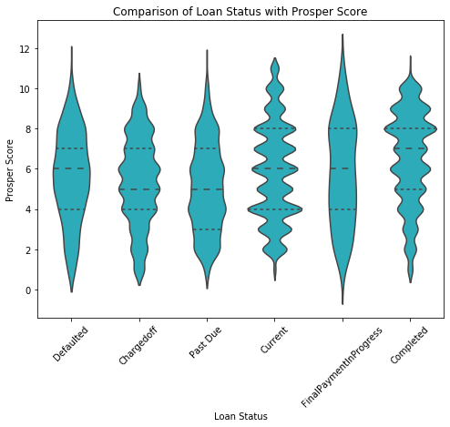

```python
f, ax = plt.subplots(figsize=(8, 6))
sb.violinplot(data=df,x='LoanStatus',y='ProsperScore',color=sb.color_palette()[9],inner='quartile')
plt.xticks(rotation=45)
ax.set_title('Comparison of Loan Status with Prosper Score')
ax.set_xlabel('Loan Status')
ax.set_ylabel('Prosper Score')
```

```python
#Deriving year column out of Listing creation date
df['ListingCreationDate']=pd.to_datetime(df['ListingCreationDate'])
df['listing_year'] = df['ListingCreationDate'].dt.year
df=df.drop(['ListingCreationDate'],1)
```

> To show the difference in loan performance among the income groups we have to write a function which provides % split within the income group among various hues with help from a stackoverflow.com thread.

```python
def with_hue(data,x,hue_y,title,xtitle):
    df1 = data.groupby(x)[hue_y].value_counts(normalize=True)
    df1 = df1.mul(100)
    df1 = df1.rename('Percent').reset_index()
    g = sb.catplot(x=x,y='Percent',hue=hue_y,kind='bar',data=df1,)
    g.ax.set_ylim(0,100)
    g.ax.set_title(title)
    g.ax.set_xlabel(xtitle)
    for p in g.ax.patches:
        txt = str(p.get_height().round().astype(int)) + '%'
        txt_x = p.get_x()
        txt_y = p.get_height()
        g.ax.text(txt_x,txt_y,txt)
```

**Monthly_Income_Range vs Quality of Loan**

> The number of bad loans as % within 2 high income group (>12.5 & 10k to 12.5k) is actually greater than the one at the middle income group (7501-10k). Now this is the type of chart that shows why data is king and motivates people like me to pursue this discipline of data analytics. Brilliant surprise although a small one !

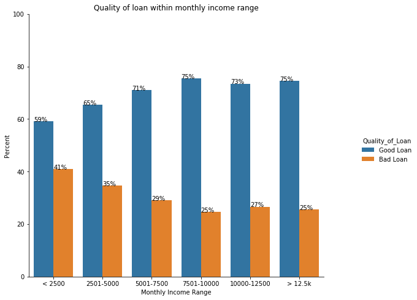

```python
with_hue(df,'Monthly_Income_Range', 'Quality_of_Loan','Quality of loan within monthly income range','Monthly Income Range')
plt.gcf().set_size_inches(10, 7)
```

**BorrowerReturn vs Loan Status**

> Bad loans (default, chargedoff, past due) have higher borrwer rate which indicates the risk built in during the rate assignment.

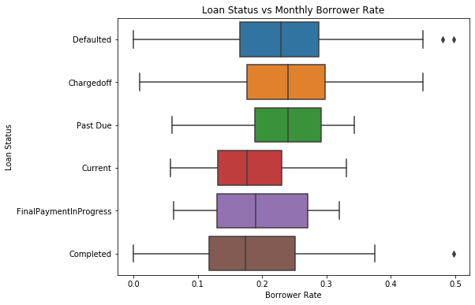

```python
f, ax = plt.subplots(figsize=(8, 6))
sb.boxplot(data = df, y='LoanStatus',x = 'BorrowerRate')
ax.set_title('Loan Status vs Monthly Borrower Rate')
ax.set_xlabel('Borrower Rate')
ax.set_ylabel('Loan Status')
```

**How Debt to Income Ratio affects borrower Rate? Hue on Credit Rating**

> This visual is a follow up to the bivariate plot of the same two parameters but with credit rating added as hue. This helps in much clearer picture of the layers within borrower rate which are stacked as per credit rating. Top layer populated heavily by high risk, with next layer on less riskier rating and so on.

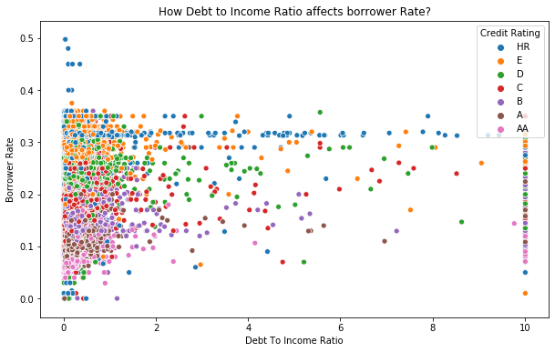

```python
f, ax = plt.subplots(figsize=(10, 6))
sb.scatterplot(data=df,y='BorrowerRate',x='DebtToIncomeRatio',hue='Credit_Rating',hue_order = ['HR','E','D','C','B','A','AA'])
plt.legend(loc=1, fontsize = 9)
handles, labels = ax.get_legend_handles_labels()
ax.legend(handles=handles[1:], labels=labels[1:], title='Credit Rating',loc=1)
ax.set_title('How Debt to Income Ratio affects borrower Rate?')
ax.set_xlabel('Debt To Income Ratio')
ax.set_ylabel('Borrower Rate')
```

**How strong is relation between Estimated Return & Borrower Rate? Hue on Credit Rating**

> Ofcourse borrower rate causes the estimated return. This visual was not explored in bivariate as the strong relationship is on expected lines but becomes much more interesting when credit rating is added as the hue. the layers are clearly visible and almost demarcated which signifies the significance of credit rating on both the variables.

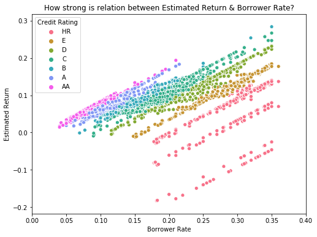

```python
f, ax = plt.subplots(figsize=(8, 6))
sb.scatterplot(data=df,x='BorrowerRate',y='EstimatedReturn',hue="Credit_Rating",hue_order = ['HR','E','D','C','B','A','AA'], palette='husl')
plt.xlim(0,0.4)
plt.legend(loc=1, fontsize = 9)
handles, labels = ax.get_legend_handles_labels()
ax.legend(handles=handles[1:], labels=labels[1:], title='Credit Rating',loc=0)
ax.set_title('How strong is relation between Estimated Return & Borrower Rate?')
ax.set_xlabel('Borrower Rate')
ax.set_ylabel('Estimated Return')
```

```python
# replacing not available with nan valies in employment status
df.EmploymentStatus.replace('Not available', np.nan, inplace=True)
```

**Who can be the possible target customer segment based on employment status? Hue on Credit rating**

> The x and y axis has been taken as Monthly income & estimated Return. The group with high risk and return seems to be Employed + Full time group with relatively lower credit rating of D & E with good loans return between 0.1 and 0.2

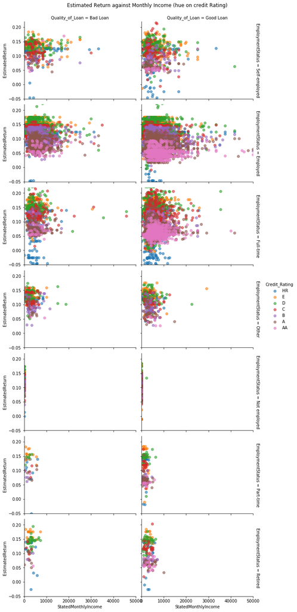

```python
g=sb.FacetGrid(data=df, row='EmploymentStatus', col='Quality_of_Loan',hue='Credit_Rating',margin_titles=True,height=3,aspect=1.5)
g.map(plt.scatter,'StatedMonthlyIncome','EstimatedReturn',alpha=0.6)
plt.xlim(0,50000)
plt.ylim(-0.05,0.22)
g.add_legend()
plt.subplots_adjust(top=0.95)
g.fig.suptitle('Estimated Return against Monthly Income (hue on credit Rating)')
```

**Did prosper score get it right when it comes to estimated return ? Hue on credit rating**

> Separating into good loan and bad loan, we notice that both looks similar in pattern except few points that stands out in the lower & middle scores.  
> 1) There seems to be many HR rated good loans which were assigned lower prosper score (0 to 4), in lower income groups (< 7500 monthly income)  
> 2) There is a good amount of AA rated good loans when compared to bad loans in the scores between 6 & 8  
> *One inference is clear, Prosper scores aren't perfect as very few things are in the world with room to improve*

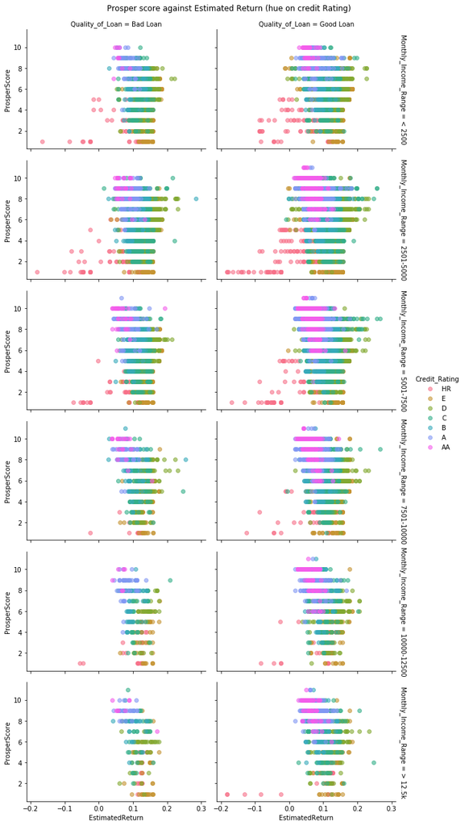

```python
g=sb.FacetGrid(data=df, row='Monthly_Income_Range', col='Quality_of_Loan',hue='Credit_Rating',margin_titles=True,height=3,aspect=1.5, palette='husl')
g.map(plt.scatter,'EstimatedReturn','ProsperScore',alpha=0.6)
g.add_legend()
plt.subplots_adjust(top=0.95)
g.fig.suptitle('Prosper score against Estimated Return (hue on credit Rating)')
```

**How strong a factor is debt to income ratio?**

> Heatmap on average debt to income ratio by Income range and Quality of loan indicates expected difference between good and bad loan with huge spike in income group of <2500

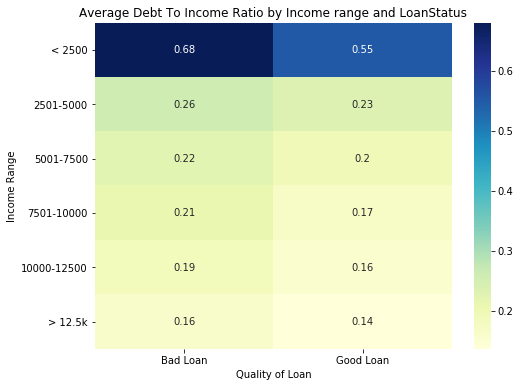

```python
heatmap_df2 = df.groupby(['Monthly_Income_Range','Quality_of_Loan']).DebtToIncomeRatio.mean().reset_index()
hm_data2 = heatmap_df2.pivot('Monthly_Income_Range','Quality_of_Loan','DebtToIncomeRatio')
fig, ax = plt.subplots(figsize=(8, 6))
ax = sb.heatmap(hm_data2,ax=ax, annot=True,cmap="YlGnBu")
ax.set_title('Average Debt To Income Ratio by Income range and LoanStatus')
ax.set_ylabel('Income Range')
ax.set_xlabel('Quality of Loan')
```

**We now know Prosper score did not get everything right. How do we quantify the key misses?**

> Second heatmap with Debt To Income Ratio average by Credit Rating over ProsperScore, shows where prosper score is high with high debt to income ratio while its very clear that the debt to income ratio is a very strong factor in loan defaults.

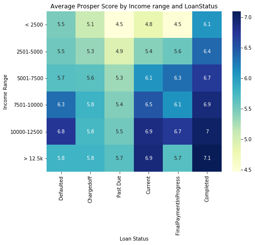

```python
heatmap_df2 = df.groupby(['Monthly_Income_Range','LoanStatus']).ProsperScore.mean().reset_index()
hm_data2 = heatmap_df2.pivot('Monthly_Income_Range','LoanStatus','ProsperScore')
fig, ax = plt.subplots(figsize=(8, 6))
ax = sb.heatmap(hm_data2,ax=ax, annot=True,cmap="YlGnBu")
ax.set_title('Average Prosper Score by Income range and LoanStatus')
ax.set_ylabel('Income Range')
ax.set_xlabel('Loan Status')
```

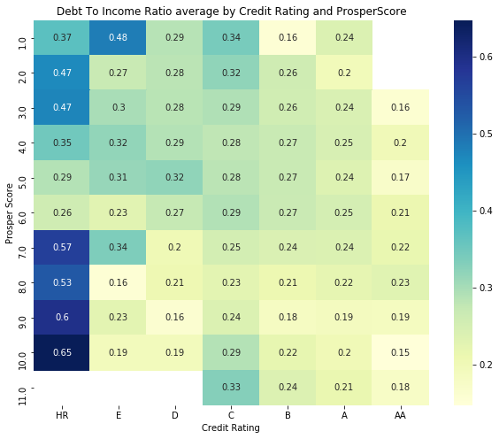

```python
heatmap_df = df.groupby(['ProsperScore','Credit_Rating']).DebtToIncomeRatio.mean().reset_index()
hm_data = heatmap_df.pivot('ProsperScore','Credit_Rating','DebtToIncomeRatio')
fig, ax = plt.subplots(figsize=(10, 8))
ax = sb.heatmap(hm_data,ax=ax, annot=True,cmap="YlGnBu")
ax.set_title('Debt To Income Ratio average by Credit Rating and ProsperScore')
ax.set_xlabel('Credit Rating')
ax.set_ylabel('Prosper Score')
```

### Key Takeways

**Points to note**

**Key misses with prosper score as a risk identification factor**

> 1) Number Defaults is almost equal on either side of prosper score of 6  
> 2) High score for high income groups with lower credit rating  
> 3) High scores for groups with high debt to income ratio

**Key factors to identify borrower riks within analysis scope**

> 1) Credit Rating  
> 2) Debt to Income Ratio, which may have accounted for in credit rating  
> 3) Prosper score